### 6월/4주

#### ▶ 정당지지도

더불어민주당 42.8%, 국민의힘 33.7%, 조국혁신당 8.3%, 개혁신당 4.5%, 기타 정당 2.8%, 지지하는 정당 없다 7.2%, 잘 모르겠다 0.6%

#### ▶ 국정평가

잘하고 있다 30.6%, 잘못하고 있다 67.3%, 잘 모르겠다 2.1%

#### ☑ 차기 대권 주자 적합도

김동연 3.0%, 안철수 1.3%, 오세훈 4.2%, 원희룡 6.4%, 이재명 40.1%, 이준석 5.3%, 조국 7.7%, 한동훈 21.6%, 홍준표 3.9%, 그 외 인물 1.8%, 없다 3.0%, 잘 모르겠다 1.5%

#### ☑ 차기 국민의힘 당대표 적합도

나경원 10.4%, 원희룡 11.1%, 윤상현 6.0%, 한동훈 32.2%, 그 외 인물 8.4%, 없다 27.5%, 잘 모르겠다 4.3%

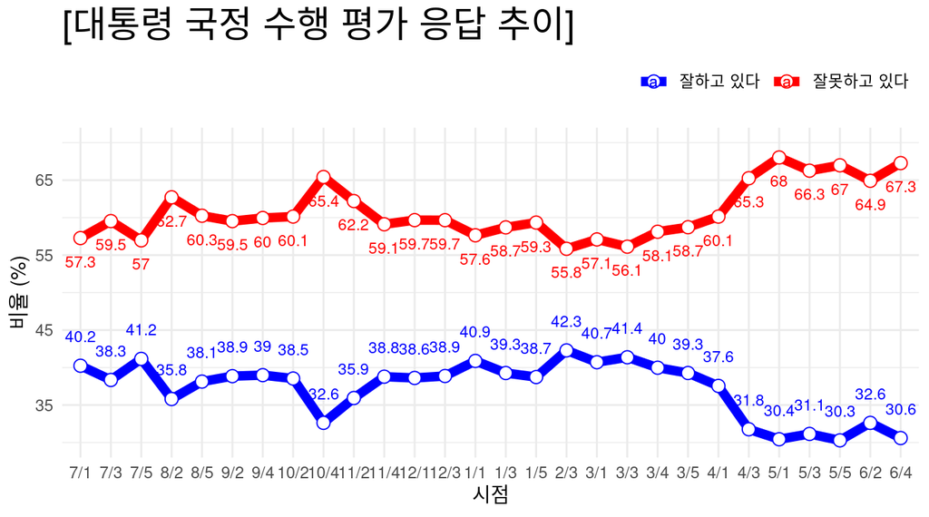

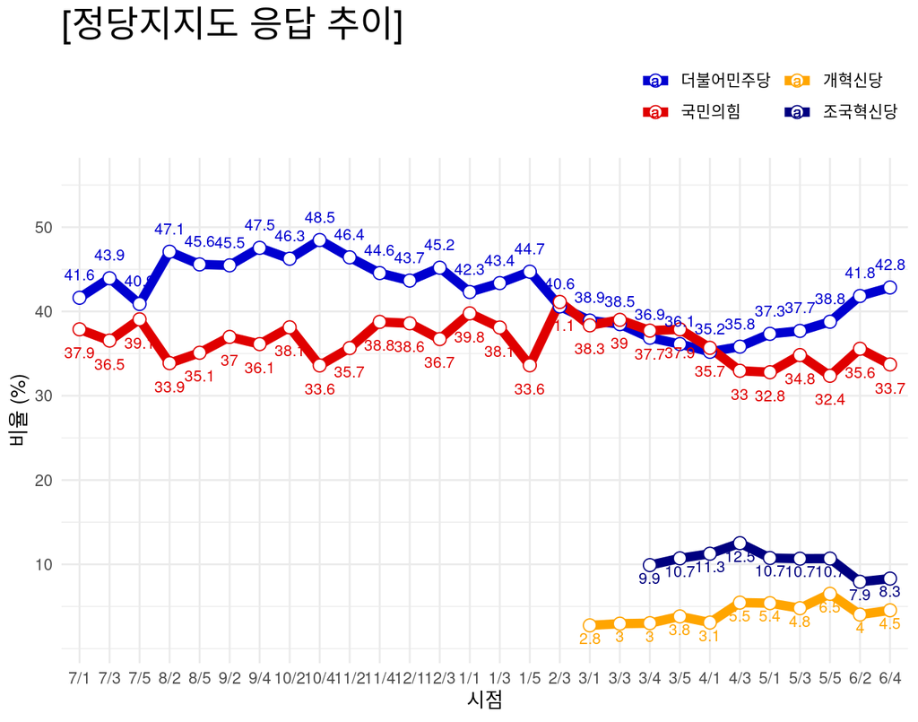

### 추가사항

- [주요질문 / 집단별 세부통계 보기](https://modernity.shinyapps.io/survey_str/) (링크누르시오)

### 참고사항

- 표본수: 2,005명,표본오차는 95% ±2.2%p
- 조사정보: 스트레이트뉴스의 의뢰로 조원씨앤아이가 2024년 6월 22일~24일 3일간

  전국 만 18세 이상 남녀를 대상으로 ARS 여론조사

  (휴대전화 100% RDD 방식, 성,연령대,지역별 비례할당 후 무작위 추출)를 실시한 결과이며,

  ※ 가중치 부여 방식: [림가중] 성별, 연령별, 지역별 가중값 부여(2024년 5월말 행정안전부 발표 주민등록인구기준)
- [중앙선거여론조사심의위원회](https://nesdc.go.kr/portal/bbs/B0000005/list.do?menuNo=200467)에서 관련사항 확인가능

2024.06.26 (Wed) 10:27 제작

- 연구개발 단계입니다.
- 제공: 감동과 마음의 [조원씨앤아이](http://jowoncni.com/html/index.html)